# The Prisoners and Hats Riddle

Lucia Baldassini

Daniëlle Metz

Julia Mol

# Introduction

For our project, we were interested in analysing riddles involving agents wearing different colours of hats. In these type of riddles, agents wear a hat (the colour usually being assigned randomly) and have to guess their hat colour. These riddles are perfect for applying Kripke models and Public Annnouncement Logic. After each agent makes an announcement (e.g. saying he is wearing a red hat), the accessible worlds of the following agents are reduced such that when it’s their turn, the agents have gained certainty about the colour of their hat because in all worlds accessible to them they all wear the same color.

In our project, we analysed two riddles, which will be briefly explained below. For Riddle 1, two possible strategies have been implemented.

The ‘Strategies’-section shows the strategies used to solve both riddles. In the ‘Analyses’-section, we provide, for each riddle and each strategy, a practical example in which Kripke models and Public Announcement Logic is directly applied. The ‘Implementation’-section provides a description of how the strategies where implemented in the programme. Lastly, in the ‘Conclusion and Further Improvements’, we include a brief discussion of the project and possibilities for further improvements.

## Description Riddle 1

You and other individuals have been captured by super-intelligent aliens! The aliens think agents look quite tasty, but - luckily for you - their civilization forbids eating highly logical and cooperative beings. Since the aliens are not sure whether you qualify, they decide to give you all a test to figure that out. The aliens tell you the following:

“You will be placed in a line, facing forward and ordered from *tallest* to *shortest*. You will not be able to look behind you or step out of the line.  
Each of you will have either a blue or a red hat (assigned randomly) and no one will be told how many of each colour hats there are. When I tell you to begin, each of you must guess the colour of their own hat, starting from the person in the back and moving down the line. Know that we notice everything! So, do not even think of saying other words than blue or red or signal something with intonation, for instance.  
**Else, you will all be eaten immediately!**  
For you to stay spared, you are allowed to make up to one mistake at most. You are given a couple of minutes to discuss a strategy before we start.”

## Description Riddle 1: Variation

In a variation of Riddle 1, the prisoners are not allowed to make any mistakes, but are allowed to pass their turn. They are not all allowed to pass. Therefore, at least one prisoner should correctly guess the colour of their hat. This variation involves an entirely different solution, which will be described in the “Strategies”-section.

## Description Riddle 2

You and other individuals are part of a tv show in which you can win a lot of money! The host of the show tells you the following:

“You will be placed in a line, facing forward and ordered from *tallest* to *shortest*. You will not be able to look behind you or step out of the line.  
Each of you will have either a red, a blue or a yellow hat (assigned randomly). When the game begins, each of you must guess the colour of their own hat, starting from the person in the back and moving down the line. Your final prize will be determined by the amount of correct guesses you make. You get $10.000 for each correct guess! You have 5 minutes to come up with a solution.”

# Strategies

## Riddle 1: First strategy

The strategy to win this game and, hence, be freed by the aliens is to agree that the tallest agent says:

- “Blue” to indicate that he sees an odd number of red hats in front of him;
- “Red” to indicate that he sees an even number of red hats in front of him.

The tallest agents does not hear any information from another agent before he has to speak. Since he cannot be entirely sure about his own hat colour, he has to guess. This is not immediately a big problem, since the aliens allowed the agents to make one mistake. Since all other agents can say with full certainty which colour their hat is, there will not be made more than one mistake in total by the group. Namely, on the basis of hearing the previous answer(s) and seeing the hats in front of them, each agent can update his beliefs and determine his own hat colour.

The game’s goal is to have as many of the agents correctly guess their hat colour. The game is successfully played if at most one mistake is made. Therefore, since only the tallest agent is unsure of his answer, the game is always played successfully if the above-mentioned technique is applied.

## Riddle 1: Second strategy

In the variation of Riddle 1, we need to apply a different strategy compared to the one explained before, as the tallest agent cannot afford to make a wrong guess to convey the odd or even number of hats. To win, the strategy for the first agent is the following:

- “Blue” to indicate that all agents in front of him are wearing a red hat.
- “Pass”, otherwise.

The strategy is the following for the other agents:

- “Blue” if all agents in front of him are wearing a red hat and all agents before him passed.
- “Red” if an agent before him said either “red” or “blue”.
- “Pass”, otherwise.

## Riddle 2

In this scenario, applying, for example, the first strategy of Riddle 1 will not help, since specifying whether there is an odd or even number of red hats will not guarentee that any of the agents guesses his hat colour correctly. To add to the difficulty, a bug is added to the room in which the prisoners discuss their strategy together. For instance, if the prisoners agree on the strategy to all answer with the word “red” (entailing that probably one third of them will have guessed correctly), the captors can sabotage them (e.g. giving none of the prisoners a red hat, so everyone guesses incorrectly).

The winning strategy is called the “Checksum Modulo-3” method. In this technique, the prisoners agree on various numbers to represent each hat colour. For example: yellow = 0, blue = 1 and red = 2. Using these numbers, the agents add up the numbers of the colours they see and perform a modulo (%) of 3 on the sum. Hence, obtaining either number 0, 1 or 2 and the corresponding colour will be the word the agent utters. In order to avoid negative numbers, all agents start with the number 30 and add the number, which corresponds to the colour uttered by the taller agent(s), to what is called the “running tally”. The next agent also calculates the sum of the hats in front of him, subtracts this number from the running tally and then performs a modulo of 3, such that they end up with their own hat colour number. The following agent(s) again subtract this resulting number from the current running tally such that when it is their turn, they all correctly call out the colour of their hat.

# Analyses

## Riddle 1

Depending on the number of agents and the hat colours assigned to each of them, there are multiple different scenarios possible. As an example, we will elaborate on the possible worlds in which a total of three agents are participating. Each of the agents is either wearing a red or blue hat. The following table indicates the 8 different scenarios that are possible in this situation. The arrows visualize the direction in which the particular agent is looking. The colour of the cell represents the agent’s hat colour.

*Table 1: The 8 different scenarios possible for 3 agents*

[output not shown]

### Example Analysis Scenario 4 using strategy 1

In order to analyze the problem, we will present an example and go through all the agents’ announcements and the changes to the Kripke model. This way, we can explore how the worlds accessible for each agent change over time.

In our example, Agent 1 (the smallest agent) is wearing a blue hat. Agent 2 (the middle agent) also wears a blue hat. Agent 3 (the tallest agent) will be wearing a red hat.

Initially, we could draw the following Kripke model: Agent 3 is unsure of only the colour of his own hat. The knowledge of Agent 2 contains worlds in which both his and Agent 3’s hat colour vary. The knowledge of Agent 1 contains all possible combinations of blue and red hats.

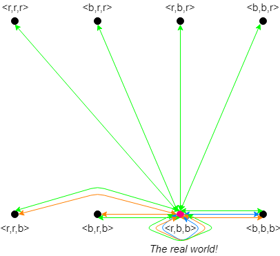

Firstly, Agent 3 will announce red to indicate that he sees an even number of red hats (namely, 0). After the announcement, Agent 2 sees a blue hat in front of him and, therefore, eliminates all the worlds in which he is wearing a red hat. In fact, it is not possible for him to wear a red hat, because, in this case, the tallest agent would have announced an odd number of red hats earlier. Since this did not happen, Agent 2 deduces that his hat colour is blue and correctly announces it. In formal terms, the formula that Agent 2 uses to update the Kripke model is: [red]‘there is an even number of red hats’.

Agent 1 also knows that there is an even number of red hats, so he applies the same updates as Agent 2 and, hence, eliminates all the worlds in which there exist an odd number of red hats. The update of Agent 1 is: [red] ‘there is an even number of red hats’.

Hence, the Kripke model is updated to:

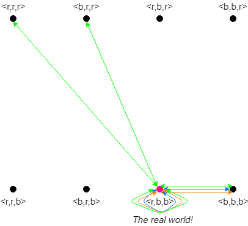

As Agent 2 announced that the colour of his hat is blue, Agent 1 updates the Kripke model with the formula [blue]‘Agent 2 is wearing blue’ and eliminates all the worlds in which Agent 2 wears a red hat.

The Kripke model is updated to:

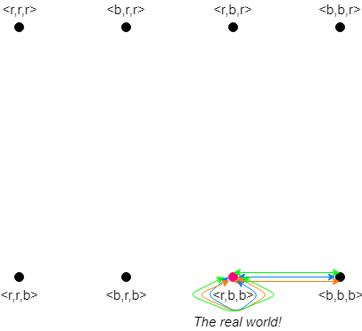

Because Agent 1 knows that there is an even number of red hats (from the first announcement) and that Agent 2 is wearing a blue hat (from the second announcement), he concludes that in the real world there are 0 red hats. Therefore, he announces that the colour of his own hat is blue, solving the riddle.

### Example Analysis Scenario 3 using strategy 2

For the second strategy, we will look at Scenario 3. In this example, Agent 1 wears a red hat. Agent 2 wears a blue hat and Agent 3 wears a red hat.

Initially, we can draw a Kripke model similar to strategy 1: Agent 3 is unsure of only the colour of his own hat. The knowledge of Agent 2 contains worlds in which both his and Agent 3’s hat colour vary. The knowledge accessible to Agent 1 contains all possible combinations of blue and red hats for a total of 3 agents.

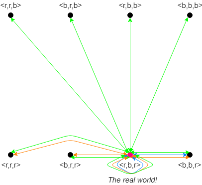

Note the similarity to the initial Kripke model in Strategy 1. For Strategy 1, the blue hats are at the bottom, for Strategy 2 they are at the top. Hence, the only thing different between the two strategies is that the worlds in which Agent 1 is wearing a blue hat and a red hat are swapped.

Now, according to the strategy, Agent 3 will pass its turn as he does not only see red hats. This announcement decreases the possible worlds for Agent 1 and Agent 2 already significantly. For both agents, the worlds in which both of them are wearing a red hat are no longer accessible.

Therefore, the Kripke model is updated to:

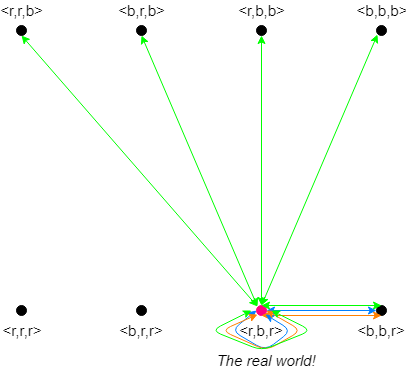

The final Kripke model looks quite familiar again:

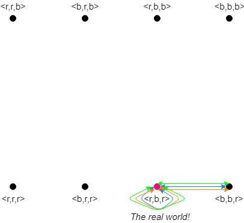

## Riddle 2

As the “Checksum Modulo-3” method might be hard to imagine, we will provide a brief example of three agents, such that we can also visualize the Kripke model. In this new scenario, Agent 3 (the tallest agent) wears a yellow hat. Agent 2 (the middle agent) wears a red hat and Agent 1 (the shortest agent) wears a blue hat.

Initially, we could draw the following Kripke model: Agent 3 is only unsure of the colour of his own hat. The knowledge accessible to Agent 2 contains worlds in which both his and Agent 3’s hat colour vary. The knowledge accessible to Agent 1 contains all possible combinations of yellow, blue and red.

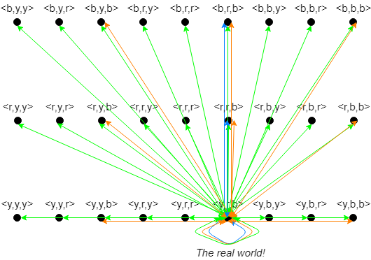

In this scenario, Agent 3 can see one red hat (=2) and one blue hat (=1). He calculates the sum (2+1=3) and performs a modulo (3%3=0). He ends up with 0, which represents yellow. Therefore, he says “yellow”.

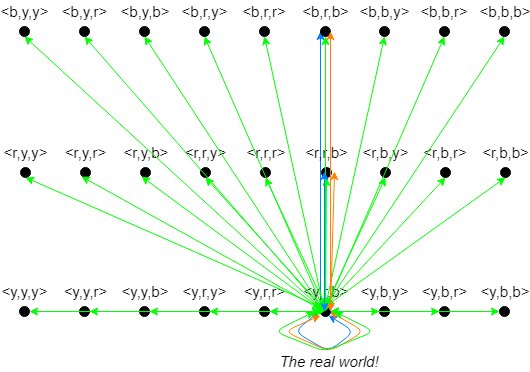

Agent 1 also updated his running tally after Agent 3’s turn, which is 30 at this point. After the utterance of Agent 2, and, therefore, after subtraction and applying the modulo of 3 to the value ((30-2)%3=1), the value is adjusted to 1. This concludes that, according to this strategy, Agent 1 is wearing a blue hat. This results in the following final Kripke model:

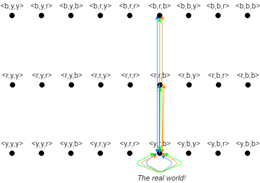

# Implementation

The programme that solves this riddle can be found [here](https://github.com/LuciaBaldassini/MAS).

The programme is written in `Python3` and requires the packages `numpy` and `pygraphviz`. The programme contains the following files: `run.py`, which is used to run the programme, `riddle1.py`and `riddle2` that contain the functions needed to implement Riddle 1 and Riddle 2, respectively. The file `Agent.py`contains the agent class and `utiliy.py` contains the functions common to both riddles.

When the user runs the programme, a description of both Riddle 1 and Riddle 2 is shown. The system then asks which riddle the user wants to choose. Regardless of which riddle is chosen, a description of the implemented strategies is shown to the user. If Riddle 1 is selected, the user has the option to solve it with one of the two possible strategies. In both riddles, the user manually selects the number of agents, although a minimum of three agents is required. This is because Riddle 2 requires at least three agents and Riddle 1 becomes too trivial if less than three agents are used. Although there is no maximum, we advice the user to choose at most 10 agents to prevent the system from becoming too slow. Each agent is created from the class `Agent()`, which stores the agent id (the shortest agent being Agent 1; and the id number increases up to the tallest agent), the colour of his own hat and the colours of the hats in front of him.

The user has also the opportunity to either manually assign the hat colours to each agent or let the colours be assigned randomly (the system can do this automatically with the function `assignRandomHat`). An overview of the distribution of the hats among the agents is then displayed.

## Riddle 1: Strategy 1

First, the initial Kripke model is created, which contains all the worlds accessible by each agent **before** any announcement is made. This is done with the function `createAgentKnowledge`. The model is created in the form of a python dictionary in which the keys contain the agent id and the values contain the accessbile worlds. The shortest agent is the one with the highest number of accessible worlds: The worlds accessible for him are all combinations of blue and red hats of length *n*, where *n* represents the number of agents in the riddle. For the other agents, the accessible worlds are those containing the hat colour of the agents they see and all possible combinations of colours for the agents behind them.

Next, the system enters the `announcementLoop()` in which each agent makes an announcement. Each announcement is stored in an array called `commonKnowledge`, which will be used later to update the Kripke model. After the first announcement is made, the worlds accessible for each agent (except the tallest one) is updated with the function `updateKripkeModel()` so that all worlds containing an even number of red hats (if the tallest agent said “blue”) or an odd number of red hats (if the tallest agent said “red”) are eliminated. The next agent in line (i.e. the second tallest agent), deduces the colour of his hat by checking if his hat colour is the same in all worlds currently accessible. If so, he announces it and the new announcement is added to the common knowledge array. In the next iteration, the Kripke model of the remaining agent(s) is updated by first eliminating all worlds in which the agent that just spoke wears a different hat color than the colour just announced and then by deleting again all worlds that contain an even/odd number of red hats (depending on the information just announced by the taller agent). The agent next in line deduces the hat colour by applying the same strategy as the previous agents. This continues in a loop until all agents have spoken.

After each agent made an announcement, the user can decide to view the updated Kripke model. In this case, a (new) graph of the Kripke model is created and saved in the same folder as the programme. The graph is created with `graphviz` and shows the real world in green, the other worlds in white and the edge labels represent the agent id (e.g. label *2* represents Agent 2). When many agents are used, due to the high number of worlds that need to be drawn, the function might output a warning (e.g. “Too many nodes”) and the graph might fail to be correctly saved. This is another reason why we advise the user to choose approximately a maximum number of 10 agents. The figure below shows an example graph, generated by the programme.

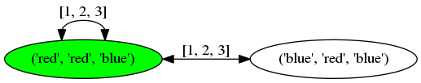

Example of Kripke model generated by the programme

When the announcement loop terminates, a function called `checkRiddle()` checks if at most one mistake has been made. This is done by comparing the `commonKnowledge` with the hat distribution input at the very beginning of the riddle. The comparison is done with `numpy.sum`, which outputs the number of dissimilar items of two arrays. If the correct strategy has been implemented, this comparison should never output more than one dissimilar item. At the end, the system outputs a friendly message such as: “Wow you are a highly intelligent specie, you will not be eaten!”.

## Riddle 1: Strategy 2

As it was the case with Strategy 1, the initial Kripke model is created in the same way as before. The announcement loop starts again and the tallest agent announces either *blue* or *pass* according to the strategy explained in the “Strategies”-section. The Kripke model for each agent is updated in the following way: First, if the tallest agent announced *blue*, all worlds are removed except the one in which all but the tallest agent are wearing a red hat. On the contrary, if the tallest agent passed, the world that was kept in the previous case is eliminated instead. The next agent in line, looks at all his accessible worlds. If in all cases he is wearing the same hat colour; he announces this colour, otherwise he passes. The Kripke model is again updated in two ways, which follow directly from the strategy explained before.

- If some agents before him announced a color, all worlds in which he is wearing a hat with this colour are eliminated.
- If all agents before him have passed and he sees nothing but red hats, all worlds in wich he is wearing a red hat are eliminated.

As earlier, the user has the option to inspect the updated Kripke model after each announcement.

Again, the agent looks at all his currently accessible worlds after the update and announces either a color or *pass*. This continues in a loop until all agents have spoken.

When the loop terminates, the function `checkRiddle()` checks if a mistake is made and if not all agent have passed. If either of these two cases were the case, the system outputs a message informing the user that all agents will be eaten.

## Riddle 2

As in the case of Riddle 1, the initial Kripke model is created in the same way as before. We also defined a dictionary in which each hat colour is associated to a number, as it was explained in the “Strategies”-section earlier. This dictionary is used throughout the programme to map colours to numbers and vice versa. We also declared an initial running tally of 30. We chose this particular value because it was the one used in the description of the riddle that we found online (however, any other multiple of 3 could have been chosen as well)[^1].

The announcement loop starts as follows: The tallest agent calculates the checksum of the hats in front of him with the function `calculateCheckSum`. This function loops over the hats that each agent sees and sums the corresponding numbers. The agent calculates the colour of his own hat by taking the checksum and applying a modulo of 3. The colour announced by the agent is added to the common knowledge and it is subtracted from the running tally. After the first announcement, the Kripke model is updated in the following way: The agent next in line (the second tallest) calculates his hat colour by calculating the checksum, subtracting it from the running tally and performing the modulo 3 division. All the worlds in which this agent is not wearing the hat colour that he just calculated, are eliminated. The announcement is then added to the common knowledge. As previously, the announcement loop continues until all agents have spoken.

At the end of the loop, a function calculates the final prize by multiplying the number of hats that were guessed correctly by 10,000.

# Conclusion and future implementations

With this project, we showed how Kripke models and Public Announcement Logic can be used to analyse riddles. Any riddle which involves announcements made by agents can be analysed in an identical way as we have presented with our riddles.

Riddle 1 was a clear example of how agents can reason about the worlds accessible to them to come up with the right conclusion. Riddle 2 was perhaps a less blatant example, since the agents, basically, only needed to apply a formula to deduce hat colours. However, a correct guess was only possible thanks to the announcement of the previous agent(s). Therefore, we decided to include that as well. We thought it was interesting to include two strategies of the same riddle to show that there exist various methods to solve a riddle.

The first strategy seems to be the most optimal one, whereas everyone is guaranteed survival in any possible scenario. We thought it was interesting to also include one which failed in one scenario. That is why we included the second strategy, because here agents could decide to pass their turn and were not only just given the option to guess their hat colour. We thought that having some variation in our programme would make the user’s experience more pleasant.

As always, there is still room for improvements. Due to time constraints, we were not able to implement these improvements ourselves (yet), however, we would like to mention these points here. For example, there could be thought of a nicer user-interface for the system. Also, in the early stages of our project, we thought of developing our programme as a phone application. However, the time assigned given for this project did not allow for this implementation, hence, we sticked to establishing a proper command-line-programme. Of course this is at the expense of nice graphics which will make the user’s experience more enjoyable. Furthermore, it would have been nice to include other types of riddles (i.e. not just hat riddles) that also use Public Announcement Logic. In this way, we could have shown that Public Announcement Logic can be applied to a wide variety of riddles. Moreover, an additional feature could have been to allow the user to create his own strategy. The programme could have dynamically updated the Kripke models according to the user’s strategy. These ideas will be starting points future projects.

[^1]: https://www.quantamagazine.org/solution-a-hat-trick-1-of-hat-puzzles-20160323